# HW4 94104778

```r
bcg <- readRDS("~/Downloads/bcg.rds")
bsg <- readRDS("~/Downloads/bsg.rds")
bsa <- readRDS("~/Downloads/bsa.rds")
bsr <- readRDS("~/Downloads/bsr.rds")
bst <- readRDS("~/Downloads/bst.rds")
btm <- readRDS("~/Downloads/btm.rds")
bts <- readRDS("~/Downloads/bts.rds")
timss <- readRDS("~/Downloads/timss_2015.rds")
```

# Q2

By dividing the educated level to two groups named educated and less educated and then applying the t.test to these groups for both mother and father I obtained p-values below which show that there are siginficiant differences between the grades of students with more educated parents and less educated parents. I divided the levels of education based on college education. By dividing the levels to two groups, the number of students in each becomes more so test would be more valid.

```r
grades <- bsg %>% mutate(grade = (bsmmat01 + bsmmat02+bsmmat03+bsmmat04+bsmmat05)/5)
mergedgradeparent <- grades %>% select(grade = grade, motheredu = bsbg07a, fatheredu = bsbg07b)
##college education
educatedmother <- mergedgradeparent %>% filter(motheredu == 6 | motheredu == 7)
educatedfather <- mergedgradeparent %>% filter(fatheredu == 6 | motheredu == 7)
mergedgradeparent<- na.omit(mergedgradeparent)
##no college education
lesseducatedmother <- mergedgradeparent %>% filter(motheredu == 1 | motheredu == 2 | motheredu == 3 | motheredu == 4)
lesseducatedfather <- mergedgradeparent %>% filter(fatheredu == 1 | motheredu == 2 | motheredu == 3| motheredu == 4)
mergedgradeparent <- mergedgradeparent[!duplicated(mergedgradeparent), ]
t.test(educatedmother$grade,lesseducatedmother$grade,alt = "two.sided")
```

```
##
##  Welch Two Sample t-test
##
## data:  educatedmother$grade and lesseducatedmother$grade
## t = 138.88, df = 120880, p-value < 2.2e-16
## alternative hypothesis: true difference in means is not equal to 0
## 95 percent confidence interval:
##  70.55316 72.57311
## sample estimates:
## mean of x mean of y
##  527.2253  455.6622
```

```r
t.test(educatedfather$grade,lesseducatedfather$grade,alt = "two.sided")
```

```
##
##  Welch Two Sample t-test
##
## data:  educatedfather$grade and lesseducatedfather$grade
## t = 115.96, df = 104130, p-value < 2.2e-16
## alternative hypothesis: true difference in means is not equal to 0
## 95 percent confidence interval:
##  63.33664 65.51452
## sample estimates:
## mean of x mean of y
##  524.1225  459.6969
```

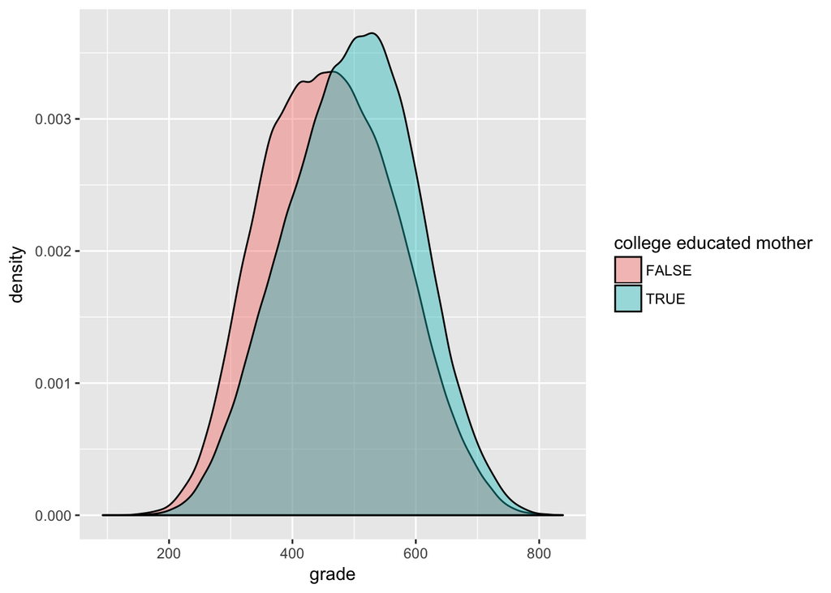

```r
ggplot(mergedgradeparent,aes(x = grade,fill = motheredu >= 6)) +
  geom_density(alpha= 0.4,na.rm = T) + labs(fill="college educated mother")
```

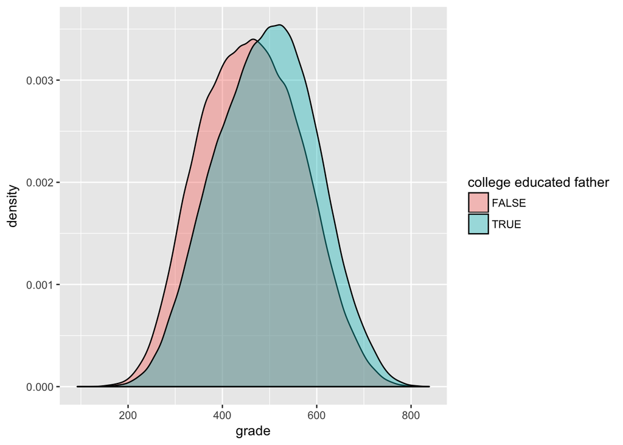

```r
ggplot(mergedgradeparent,aes(x = grade,fill = fatheredu >= 6)) +
  geom_density(alpha= 0.4,na.rm = T) + labs(fill="college educated father")
```

```r
hchart(density(educatedmother$grade), type = "area",name = "more educated mother") %>% hc_add_series(density(lesseducatedmother$grade), type = "area",name = "less educated mother")
```

[interactive chart not shown]

```r
hchart(density(educatedfather$grade), type = "area",name = "more educated father") %>% hc_add_series(density(lesseducatedfather$grade), type = "area",name = "less educated father")
```

[interactive chart not shown]

# Q10

According to p-value, we cant conclude that there is a significant difference between Iranian’s reasoning and applying in both math and science.

```r
iran <- bsg %>% filter(idcntry == 364) %>% mutate(applyscore = ((bsmapp01 +  bsmapp02 + bsmapp03+ bsmapp04+ bsmapp05)/5 + (bssapp01+ bssapp02+ bssapp03+ bssapp04+ bssapp05)/5)/2 , reasonscore = (bsmrea01+ bsmrea02+ bsmrea03+ bsmrea04+ bsmrea05 + bssrea01+bssrea02+bssrea03+bssrea04+bssrea05)/10)
t.test(iran$applyscore, iran$reasonscore, alt = "less")
```

```
##
##  Welch Two Sample t-test
##
## data:  iran$applyscore and iran$reasonscore
## t = 0.40608, df = 12235, p-value = 0.6577
## alternative hypothesis: true difference in means is less than 0
## 95 percent confidence interval:
##      -Inf 3.176549
## sample estimates:
## mean of x mean of y
##  452.3870  451.7581
```

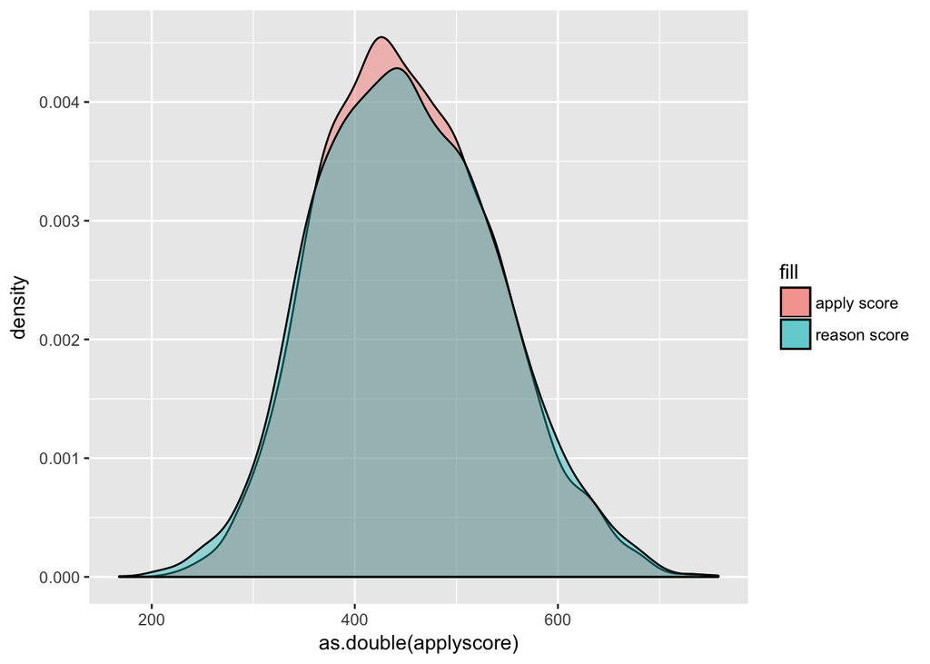

```r
ggplot(iran) + geom_density(aes(x = as.double(applyscore), fill = "apply score"),alpha = 0.4) + geom_density(aes(x = as.double(reasonscore), fill = "reason score"),alpha = 0.4)
```

```r
hchart(density(iran$applyscore), type = "area",name = "apply score") %>% hc_add_series(density(iran$reasonscore), type = "area",name = "reason score")
```

[interactive chart not shown]

# Q9

According to p-value there is a significiant difference between grades of those student who participate more and those who participate less. I have divided the students to two groups one with once a week and once every two weeks which candidates for more absents and one with once a month and almost never which candidates for less absents.

```r
absents <- grades %>% select(bsbg11, grade)
absents <- na.omit(absents)
moreabs <- absents %>% filter(bsbg11 == 1 | bsbg11 == 2)
lessabs <- absents %>% filter(bsbg11 == 3 | bsbg11 == 4)
t.test(moreabs$grade, lessabs$grade,alt = "two.sided")
```

```
##
##  Welch Two Sample t-test
##
## data:  moreabs$grade and lessabs$grade
## t = -142.86, df = 61011, p-value < 2.2e-16
## alternative hypothesis: true difference in means is not equal to 0
## 95 percent confidence interval:
##  -76.24575 -74.18196
## sample estimates:
## mean of x mean of y
##  413.7636  488.9774
```

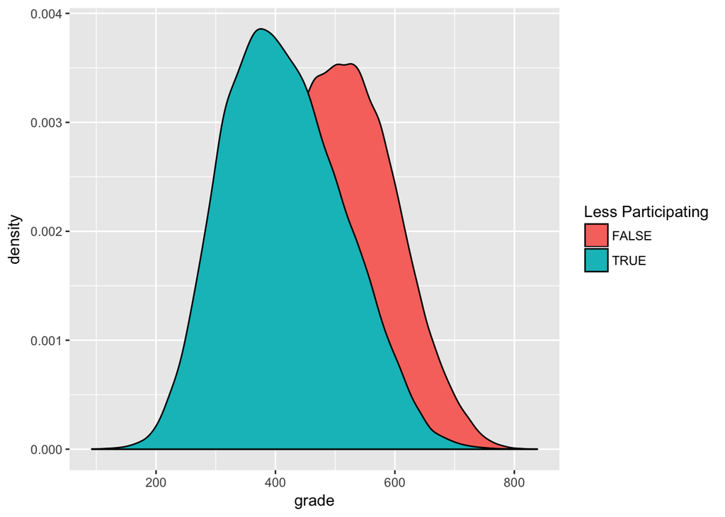

```r
ggplot(absents) + geom_density(aes(x = grade, fill = bsbg11 == 1 | bsbg11 == 2))  + labs(fill="Less Participating")
```

```r
hchart(density(moreabs$grade), type = "area",name = "Students grade with more absents") %>% hc_add_series(density(lessabs$grade), type = "area",name = "Students grade with less absents")
```

[interactive chart not shown]

# Q6

According to p-value we cant conlude that there is a significant difference between boys and girls in applyign geometry.

```r
applyinggeo <- timss %>% filter(cognitive_domain == "Applying", content_domain == "Geometry")
girls =applyinggeo  %>% select(correct_ratio_per_question_female)
boys = applyinggeo %>% select(correct_ratio_per_question_male)
t.test(boys,girls,alt = "two.sided")
```

```
##
##  Welch Two Sample t-test
##
## data:  boys and girls
## t = -0.23614, df = 1493.7, p-value = 0.8134
## alternative hypothesis: true difference in means is not equal to 0
## 95 percent confidence interval:
##  -0.02430046  0.01907826
## sample estimates:
## mean of x mean of y
## 0.4086124 0.4112235
```

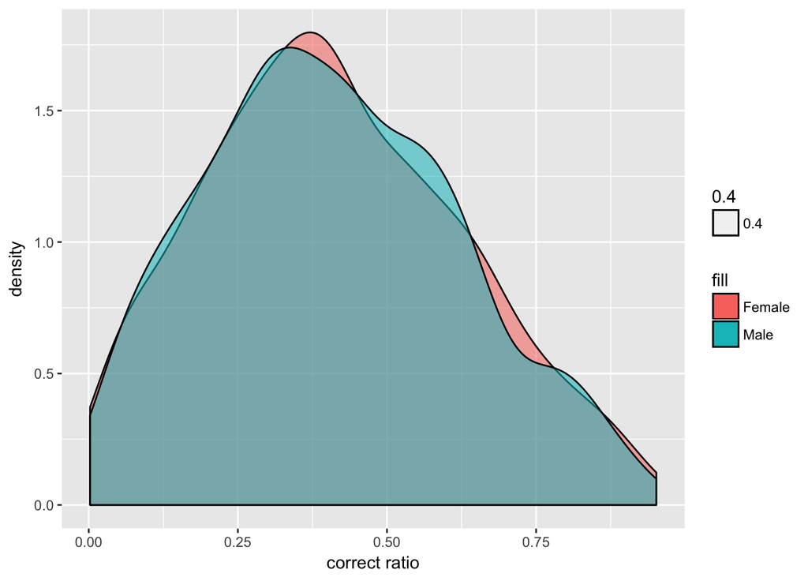

```r
ggplot(applyinggeo) + geom_density(aes(x = correct_ratio_per_question_female,fill  = "Female",alpha = 0.4)) + geom_density(aes(x = correct_ratio_per_question_male,fill = "Male",alpha = 0.4)) + xlab("correct ratio")
```

```r
hchart(density(applyinggeo$correct_ratio_per_question_female), type = "area",name = "correct_ratio_per_question_female") %>% hc_add_series(density(applyinggeo$correct_ratio_per_question_male), type = "area", name = "correct_ratio_per_question_male")
```

[interactive chart not shown]

# Q3

I have applied t-test and also correlation test on this data. It seems that there is no powerful linear relation between home facilities and grades of student according to correlation coeefficient that is -0.3. but p-value of t-test shows that there is a significiant difference between grades of two groups.

```r
homefac <- grades %>% mutate(homef = (bsbg06a + bsbg06b +bsbg06c+bsbg06d+bsbg06e+bsbg06f+bsbg06g)) %>% select(homef, grade)
homefac<- na.omit(homefac)

morefac <- homefac %>% filter(homef == 7 | homef == 8 | homef == 9 | homef == 10 )
lessfac <- homefac %>% filter(homef == 11 | homef == 12 | homef == 13 | homef == 14 )
t.test(morefac$grade, lessfac$grade,alt= "two.sided")
```

```
##
##  Welch Two Sample t-test
##
## data:  morefac$grade and lessfac$grade
## t = 150.51, df = 58006, p-value < 2.2e-16
## alternative hypothesis: true difference in means is not equal to 0
## 95 percent confidence interval:
##  78.92969 81.01251
## sample estimates:
## mean of x mean of y
##  491.9334  411.9623
```

```r
cor.test(homefac$grade,homefac$homef, data = homefac)
```

```
##
##  Pearson's product-moment correlation
##
## data:  homefac$grade and homefac$homef
## t = -170.22, df = 262560, p-value < 2.2e-16
## alternative hypothesis: true correlation is not equal to 0
## 95 percent confidence interval:
##  -0.3187018 -0.3118121
## sample estimates:
##        cor
## -0.3152611
```

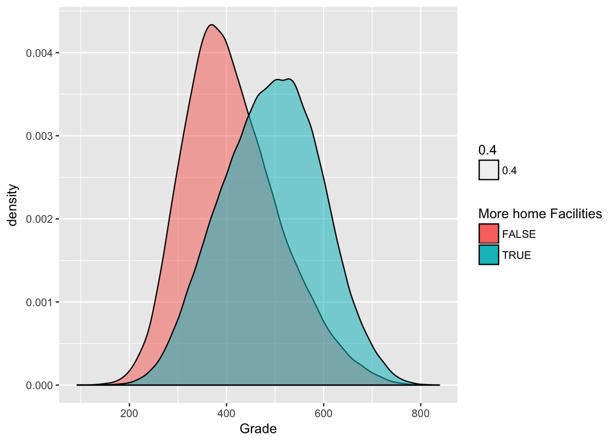

```r
ggplot(homefac) + geom_density(aes(x = as.double(grade),fill  = homef == 7 | homef == 8 | homef == 9 | homef == 10 ,alpha = 0.4))  + xlab("Grade") + labs(fill="More home Facilities")
```

```r
hchart(density(morefac$grade), type = "area",name = "More home Facilities") %>% hc_add_series(density(lessfac$grade), type = "area",name = "Less home Facilities")
```

[interactive chart not shown]

# Q4

According to the test and the p-value and also the chart we wee that grades of students who feel more safe at school are better than ones who don’t. As we can see there is a more significiant difference between those who said that they are disagree a lot with feeling safe at school with other groups.

```r
safety <- grades %>% select(bsbg15b, grade)
safe <-aov(grades$grade ~ bsbg15b , data = safety)
summary(safe)
```

```
##                 Df    Sum Sq Mean Sq F value Pr(>F)
## bsbg15b          1 5.394e+06 5393815   487.4 <2e-16 ***
## Residuals   274076 3.033e+09   11066
## ---
## Signif. codes:  0 '***' 0.001 '**' 0.01 '*' 0.05 '.' 0.1 ' ' 1
## 6052 observations deleted due to missingness
```

```r
safety <- na.omit(safety)
verysafe <- safety %>% filter(bsbg15b == 1)
vsafe <- safety %>% filter(bsbg15b == 2)
nsafe <- safety %>% filter(bsbg15b == 3)
vnsafe <- safety %>% filter(bsbg15b == 4)

hchart(density(verysafe$grade), type = "area",name = "very safe") %>% hc_add_series(density(vsafe$grade), type = "area",name = "safe") %>% hc_add_series(density(nsafe$grade), type = "area",name = "not safe") %>% hc_add_series(density(vnsafe$grade), type = "area",name = "very not safe")
```

[interactive chart not shown]

# Q8

```r
meangradeschool <- grades %>% group_by(idschool,idcntry) %>% summarise(meanscore = mean(grade))
fac <- bcg %>% mutate(schoolfac = (bcbg12+bcbg11a+bcbg11b+bcbg08a+bcbg08b+bcbg06a+bcbg06b)) %>%  select(idschool, idcntry, schoolfac)
data <- merge(fac,meangradeschool, by= c("idschool", "idcntry"))
data<- na.omit(data)

lessfac <- data %>% filter(schoolfac == 14 |schoolfac == 13 |schoolfac == 12 | schoolfac == 11)
morefac <- data %>% filter(schoolfac == 7 |schoolfac ==8 |schoolfac == 9 | schoolfac == 10)
t.test(lessfac$meanscore, morefac$meanscore,alt = "two.sided")
```

```
##
##  Welch Two Sample t-test
##
## data:  lessfac$meanscore and morefac$meanscore
## t = 2.6819, df = 2955.4, p-value = 0.007362
## alternative hypothesis: true difference in means is not equal to 0
## 95 percent confidence interval:
##   1.889405 12.164490
## sample estimates:
## mean of x mean of y
##  506.3642  499.3372
```

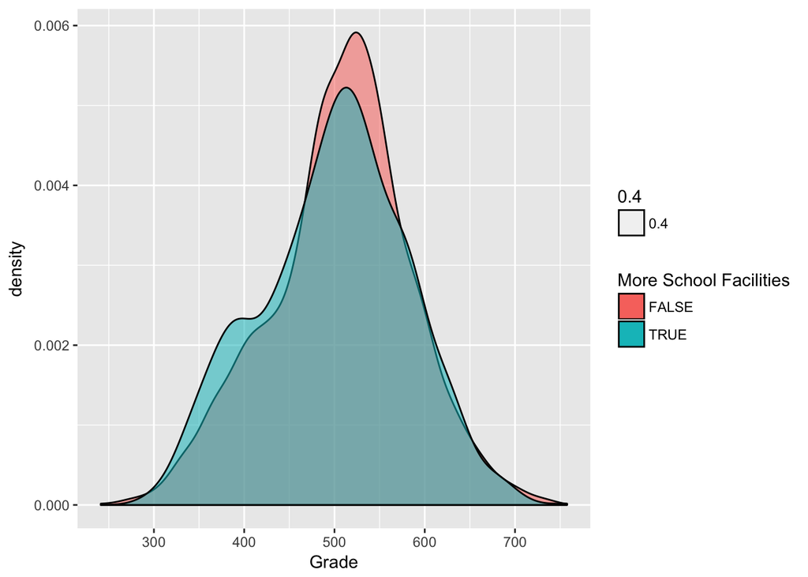

```r
ggplot(data) + geom_density(aes(x = as.double(meanscore),fill  = schoolfac == 7 |schoolfac ==8 |schoolfac == 9 | schoolfac == 10 ,alpha = 0.4))  + xlab("Grade") + labs(fill="More School Facilities")
```

```r
hchart(density(lessfac$meanscore), type = "area",name = "Less school Facilities") %>% hc_add_series(density(morefac$meanscore), type = "area" , name = "More School Facilities")
```

[interactive chart not shown]

First Statment: Girls want to continue their education to higher level than boys. We will use Wilcoxon test to examine this statment. as we see the statment is true.

```r
howfar <- grades %>% select(bsbg08, itsex)
girlhowfar <- howfar %>% filter(itsex == 1)
boyhowfar <- howfar%>% filter(itsex == 2)
girlhowfar <- na.omit(girlhowfar)
boyhowfar <- na.omit(boyhowfar)

wilcox.test(girlhowfar$bsbg08, boyhowfar$bsbg08, alternative = "greater")
```

```
##
##  Wilcoxon rank sum test with continuity correction
##
## data:  girlhowfar$bsbg08 and boyhowfar$bsbg08
## W = 1.0259e+10, p-value < 2.2e-16
## alternative hypothesis: true location shift is greater than 0
```

```r
mean(girlhowfar$bsbg08,na.rm = T)
```

```
## [1] 4.837869
```

```r
mean(boyhowfar$bsbg08,na.rm = T)
```

```
## [1] 4.488758
```

```r
hchart(density(girlhowfar$bsbg08), type = "area",name = "Girls") %>% hc_add_series(density(boyhowfar$bsbg08), type = "area",name = "Boys")
```

[interactive chart not shown]

```r
mathinterest = grades %>% select(bsbm17c, itsex)
girlintrested <- mathinterest %>% filter(itsex == 1)
boyinterested <- mathinterest %>% filter(itsex == 2)
girlintrested <- na.omit(girlintrested)
boyinterested <- na.omit(boyinterested)
wilcox.test(girlintrested$bsbm17c, boyinterested$bsbm17c, alternative = "two.sided")
```

```
##
##  Wilcoxon rank sum test with continuity correction
##
## data:  girlintrested$bsbm17c and boyinterested$bsbm17c
## W = 8897400000, p-value < 2.2e-16
## alternative hypothesis: true location shift is not equal to 0
```

```r
hchart(density(girlintrested$bsbm17c), type = "area",name = "Girls") %>% hc_add_series(density(boyinterested$bsbm17c), type = "area",name = "Boys")
```

[interactive chart not shown]

```r
internetusin = grades %>% mutate(internet = bsbg14a + bsbg14b +bsbg14c +bsbg14d +bsbg14e +bsbg14f) %>% select(grade,internet)
lessuse <- internetusin %>% filter(internet == 12 | internet == 11 | internet == 10 | internet == 9)
moreuse <- internetusin %>% filter(internet == 6 | internet == 7 | internet == 8 )
t.test(lessuse$grade, moreuse$grade, alt = "two.sided")
```

```
##
##  Welch Two Sample t-test
##
## data:  lessuse$grade and moreuse$grade
## t = -6.7051, df = 263100, p-value = 2.017e-11
## alternative hypothesis: true difference in means is not equal to 0
## 95 percent confidence interval:
##  -3.543063 -1.940237
## sample estimates:
## mean of x mean of y
##  479.4311  482.1727
```

```r
hchart(density(lessuse$grade), type = "area",name = "less use of internet") %>% hc_add_series(density(moreuse$grade), type = "area",name = "more use of internet")
```

[interactive chart not shown]